# Analysis of results AST set

2024-10-07

# Introduction

This notebook compares the results obtained using the `scanner.R` and `DGW.py` scripts. The objective is to assess whether both tools are yielding the same results, and if that is not the case, identify areas of opportunity to improve the scripts. In addition, the outputs from the scripts will be compared to the mutations found for those genomes in MicroBIGG-E.

# Setup

A total of 928 genome accession IDs for carbapenem resistant and sensitive *Pseudomonas aeruginosa* and *Klebsiella pneumoniae* were obtained from Antimicrobial susceptibility test (AST) data as follows:

*Pseudomonas aeruginosa* 359 isolates

- 292 with resistant phenotype
- 67 with sensitive phenotype

*Klebsiella pneumoniae* 569 isolates

- 297 with resistant phenotype
- 272 with sensitive phenotype

The accession numbers for these genomes are found in the project repository [here](https://github.com/NCBI-Codeathons/amr-2024-team-prasad-feldgarden/tree/main/data/dev-examples/resis_and_sens_Kp_and_Pa).

## MicroBIGG-E subset

A subset of the data available in MicroBIGG-E for the selected isolates was obtained from BigQuery and stored in the repository [here](https://github.com/NCBI-Codeathons/amr-2024-team-prasad-feldgarden/blob/main/results/microbigge_subset.csv).

## DGW results: `scanner.R` and `DGW.py`

The scripts were ran as described [here](https://github.com/NCBI-Codeathons/amr-2024-team-prasad-feldgarden/tree/main/data/resis_and_sens_Kp_and_Pa).

## Combining output files

Individual output files for each genome screened were combined using the `results_combined.R` script ([here](https://github.com/NCBI-Codeathons/amr-2024-team-prasad-feldgarden/blob/3e9bb4e9dc2196f7f8f5ad2c5055133ebd35a87d/results/scanner.R_AST/results_combined.R)).

The combined output files from each script (`DGW.py` and `scanner.R`) were combined and modeled running the `dgw_combined_outputs.sql` model ([here](https://github.com/NCBI-Codeathons/amr-2024-team-prasad-feldgarden/blob/main/results/script_comparison/dgw_combined_outputs.sql)) in `DuckDB`.

# Analysis of results

```r
# Install packges
library(tidyverse)
library(dplyr)


# Import data

## Microbigg-E subset
microbigge <-  read_csv("results/microbigge_subset_ast.csv")

## Combined and modeled output from both scanner.R and DGW.py scripts
dgw_combined_outputs <- read_csv("results/script_comparison/dgw_combined_outputs.csv")
```

Let’s first prepare the data to establish the comparisons/analysis.

### How many lesions are detected by each script?

- `DWG.py` identified 522 lesions
- `scanner.R` identified 506 lesions

```r
dgw_combined_outputs %>%
  summarize(mutations_p = n_distinct(p_mutation_id, na.rm = TRUE),
            mutations_r = n_distinct(r_mutation_id, na.rm = TRUE)
  )
```

```
## # A tibble: 1 × 2
##   mutations_p mutations_r
##         <int>       <int>
## 1         522         506
```

### How many lesions are found by both scripts?

- `DWG.py` and `scanner.R` identified the lesions in the same 509 genomes
  - 416 of those are the same lesions

```r
dgw_combined_outputs %>%
  filter(!is.na(p_mutation_id) & !is.na(r_mutation_id)) %>%
  summarize(in_both = n_distinct(record_id, na.rm = TRUE),
            same = n_distinct(case_when(p_mutation_id == r_mutation_id ~ record_id), na.rm = TRUE)
  )
```

```
## # A tibble: 1 × 2
##   in_both  same
##     <int> <int>
## 1     509   416
```

### Which records have mutations identified by both scripts, but with different lesions identified by each script?

- There were 93 records where a mutation was identified by both `DGW.py` and `scanner.R`, but the lesions identified by each script were different
  - Of these, 3 records also reported mutations in Microbigg-E, which were not the same as the ones reported by the DGW scripts

```r
DT::datatable(dgw_combined_outputs %>%
  filter(!is.na(p_mutation_id)  & !is.na(r_mutation_id) & p_mutation_id != r_mutation_id ) %>%
  select(asm_acc, p_element_symbol, r_element_symbol, mb_element_symbol, p_lesion, r_lesion, mb_lesion)
)
```

|  | asm_acc | p_element_symbol | r_element_symbol | mb_element_symbol | p_lesion | r_lesion | mb_lesion |
| --- | --- | --- | --- | --- | --- | --- | --- |
| 1 | GCA_000534095.1 | OmpK36 | OmpK36 |  | K27fs | K27STOP |  |
| 2 | GCA_000534135.1 | OmpK36 | OmpK36 |  | G17fs | A16fs |  |
| 3 | GCA_000567165.1 | OmpK36 | OmpK36 |  | D198fs | G198fs |  |
| 4 | GCA_000567625.1 | OmpK35 | OmpK35 |  | L63fs | G62fs |  |
| 5 | GCA_000567745.1 | OmpK36 | OmpK36 |  | V115fs | N115fs |  |
| 6 | GCA_000694615.1 | OmpK35 | OmpK35 |  | S301fs | F300fs |  |
| 7 | GCA_001704235.1 | OmpK35 | OmpK35 |  | K95fs | T96fs |  |
| 8 | GCA_001720865.1 | OmpK35 | OmpK35 |  | D69fs | N70fs |  |
| 9 | GCA_001874805.1 | OprD | oprD |  | L237fs | Y237STOP |  |
| 10 | GCA_001874875.1 | OmpK35 | OmpK35 |  | K95fs | T96fs |  |

[output cut: 83 more lines]

### How many lesions are detected only by `DGW.py`?

- `DGW.py` identified 19 records that `scanner.R` did not identify.
  - One of those records was also present in Microbigg-E but reporting a different lesion

```r
DT::datatable(dgw_combined_outputs %>%
  filter(!is.na(p_mutation_id) & is.na(r_mutation_id)) %>%
  select(asm_acc, p_element_symbol, mb_element_symbol, p_lesion, mb_lesion)
  )
```

|  | asm_acc | p_element_symbol | mb_element_symbol | p_lesion | mb_lesion |
| --- | --- | --- | --- | --- | --- |
| 1 | GCA_000937495.2 | NalD |  | P151fs |  |
| 2 | GCA_001874695.1 | OmpK35 |  | Y310STOP |  |
| 3 | GCA_003074115.1 | NalD |  | Q133fs |  |
| 4 | GCA_003324255.1 | NalD |  | S82fs |  |
| 5 | GCA_003324295.1 | NalD |  | M131fs |  |
| 6 | GCA_003951185.1 | OmpK35 |  | K38fs |  |
| 7 | GCA_003951185.1 | OmpK36 |  | E78STOP |  |
| 8 | GCA_003951235.1 | OmpK36 |  | L304fs |  |
| 9 | GCA_003969305.1 | OprD | oprD | S401fs | V359L |
| 10 | GCA_003969485.1 | OprD |  | S403fs |  |

[output cut: 9 more lines]

### How many lesions are detected only by `scaner.R`?

- `scanner.R` identified 3 records that `DGW.py` did not identify
  - None of those mutations were present in Microbigg-E

```r
DT::datatable(dgw_combined_outputs %>%
  filter(!is.na(r_mutation_id) & is.na(p_mutation_id)) %>%
  select(asm_acc, r_element_symbol, mb_element_symbol, r_lesion, mb_lesion)
  )
```

|  | asm_acc | r_element_symbol | mb_element_symbol | r_lesion | mb_lesion |
| --- | --- | --- | --- | --- | --- |
| 1 | GCA_000692155.1 | OmpK36 |  | Q92fs |  |
| 2 | GCA_014840405.1 | OmpK35 |  | K3fs |  |
| 3 | GCA_022299835.1 | OmpK36 |  | V3STOP |  |

## How many of the lesions detected by each script are in Microbigg-E?

- Of the 250 lesions found in Microbigg-E
  - `DGW.py` identified 134
  - `scanner.R` identified 133 (also identified by `DGW.py`)

```r
DT::datatable(dgw_combined_outputs %>%
  summarize(in_microbigge = n_distinct(case_when(!is.na(mb_element_symbol) ~ record_id), na.rm = TRUE),
            mb_p = n_distinct(case_when(!is.na(mb_element_symbol) & !is.na(p_element_symbol) ~ record_id), na.rm = TRUE),
            mb_r = n_distinct(case_when(!is.na(mb_element_symbol) & !is.na(r_element_symbol) ~ record_id), na.rm = TRUE),
            mb_combined = n_distinct(case_when(!is.na(mb_element_symbol) & (!is.na(p_element_symbol) | !is.na(r_element_symbol)) ~ record_id), na.rm = TRUE),
            mb_in_both = n_distinct(case_when(!is.na(mb_element_symbol) & !is.na(p_element_symbol) & !is.na(r_element_symbol) ~ record_id), na.rm = TRUE)
  )
)
```

|  | in_microbigge | mb_p | mb_r | mb_combined | mb_in_both |
| --- | --- | --- | --- | --- | --- |
| 1 | 250 | 134 | 133 | 134 | 133 |

## How many of the lesions detected by each script are NOT in Microbigg-E? (i.e. new mutations)

- The DGW scripts identified 397 lesions that were not present in Microbigg-E
  - 361 of which were found in resistant isolates
    - `DGW.py` identified 358 new lesions
    - `scanner.R` identified 344
    - 341 of the new lesions were identified by both scripts

```r
DT::datatable(dgw_combined_outputs %>%
  filter(!grepl("sensitive", cohort)) %>%
  summarize(new_p = n_distinct(case_when(is.na(mb_element_symbol) & !is.na(p_element_symbol) ~ record_id), na.rm = TRUE),
            new_r = n_distinct(case_when(is.na(mb_element_symbol) & !is.na(r_element_symbol) ~ record_id), na.rm = TRUE),
            new_combined = n_distinct(case_when(is.na(mb_element_symbol) & (!is.na(p_element_symbol) | !is.na(r_element_symbol)) ~ record_id), na.rm = TRUE),
            new_in_both = n_distinct(case_when(is.na(mb_element_symbol) & !is.na(p_element_symbol) & !is.na(r_element_symbol) ~ record_id), na.rm = TRUE)
  )
)
```

|  | new_p | new_r | new_combined | new_in_both |
| --- | --- | --- | --- | --- |
| 1 | 358 | 344 | 361 | 341 |

[figure not shown]

### Which genes have different lesions identified by each script compared against the lesions in Microbigg-E?

```r
DT::datatable(dgw_combined_outputs %>%
  filter((mb_element_symbol == p_element_symbol | mb_element_symbol == r_element_symbol) & (mb_lesion != p_lesion | mb_lesion != r_lesion)) %>%
  select(asm_acc,
         element_symbol = mb_element_symbol,
         mb_lesion,
         p_lesion,
         r_lesion)
  )
```

|  | asm_acc | element_symbol | mb_lesion | p_lesion | r_lesion |
| --- | --- | --- | --- | --- | --- |
| 1 | GCA_001875205.1 | oprD | V359L | L42fs | L42fs |
| 2 | GCA_002968515.1 | oprD | V359L | V125fs | G124fs |
| 3 | GCA_003000755.1 | oprD | V359L | W65STOP | W65STOP |
| 4 | GCA_003073795.1 | oprD | V359L | W65STOP | W65STOP |
| 5 | GCA_003968115.1 | oprD | V359L | W417STOP | W417STOP |
| 6 | GCA_003968275.1 | oprD | V359L | Q424STOP | Q424STOP |
| 7 | GCA_003969965.1 | oprD | V359L | T72fs | T71fs |
| 8 | GCA_003970625.1 | oprD | V359L | G110fs | M111fs |
| 9 | GCA_021712775.1 | oprD | V359L | Q166STOP | Q166STOP |

### How many lesions in Microbigg-E are not detected by the DGW scripts? (show lesions)

- Out of the 250 mutations present in Microbigg-E, 116 were missed by both DGW scripts
  - `DGW.py` missed 116 Microbigg-E mutations
  - `scanner.R` missed 117 Microbigg-E mutations

```r
DT::datatable(dgw_combined_outputs %>%
  summarize(in_microbigge = n_distinct(case_when(!is.na(mb_element_symbol) ~ record_id), na.rm = TRUE),
            missed_from_microbigge = n_distinct(case_when(!is.na(mb_element_symbol) & (is.na(p_element_symbol) | is.na(r_element_symbol)) ~ record_id), na.rm = TRUE),
            p_missed_from_microbigge = n_distinct(case_when(!is.na(mb_element_symbol) & is.na(p_element_symbol) ~ record_id), na.rm = TRUE),
            r_missed_from_microbigge = n_distinct(case_when(!is.na(mb_element_symbol) & is.na(r_element_symbol) ~ record_id), na.rm = TRUE)
  )
)
```

|  | in_microbigge | missed_from_microbigge | p_missed_from_microbigge | r_missed_from_microbigge |
| --- | --- | --- | --- | --- |
| 1 | 250 | 117 | 116 | 117 |

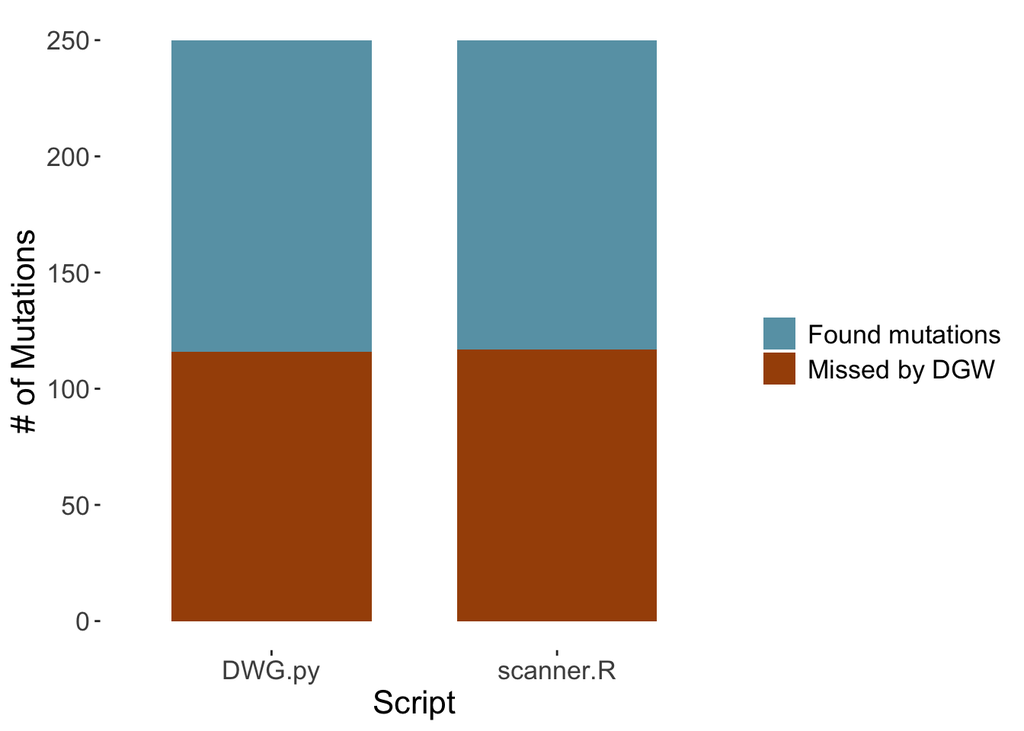

```r
DT::datatable(dgw_combined_outputs %>%
               filter (!is.na(mb_element_symbol) & (is.na(p_element_symbol) | is.na(r_element_symbol))) %>%
               select(asm_acc, mb_element_symbol, mb_lesion, p_lesion, r_lesion)
  )
```

|  | asm_acc | mb_element_symbol | mb_lesion | p_lesion | r_lesion |
| --- | --- | --- | --- | --- | --- |
| 1 | GCA_000408985.1 | ompK36 | D135DGD |  |  |
| 2 | GCA_000566945.1 | ompK36 | D135DGD |  |  |
| 3 | GCA_000566985.1 | ompK36 | D135DGD |  |  |
| 4 | GCA_000567625.1 | ompK36 | D135DGD |  |  |
| 5 | GCA_000694895.1 | ompK36 | D135DGD |  |  |
| 6 | GCA_000709225.1 | ompK36 | D135DGD |  |  |
| 7 | GCA_000937495.2 | oprD | W339STOP |  |  |
| 8 | GCA_001709275.1 | ompK36 | D135DGD |  |  |
| 9 | GCA_001875105.1 | ompK36 | D135DGD |  |  |
| 10 | GCA_001875205.1 | oprD | V359L |  |  |

[output cut: 107 more lines]